# Survival Analysis: Acute-on-Chronic Kidney Disease in Cats

### Wendy Hu

**Final Project for UCLAX CSX4501**

*In this project, we analyze data relating to acute-on-chronic kidney disease (ACKD) in cats. We use exploratory data analysis to identify biological and environmental variables that are correlated or anti-correlated with survival times, build machine learning classifier models to predict survival at 100 days and 500 days after an acute kidney failure event, and test and compare model performance for 3 trained classifers. On test sets, the logistic regression classifier achieved on average 74% accuracy in predicting survival at 100 days and 80% accuracy in predicting survival at 500 days, and outperformed the histogram gradient boosting and support vector classifiers.*

1. Introduction  
   1.1 Background and motivation  
   1.2 Objective  
   1.3 Dataset source
2. Exploratory Data Analysis  
   2.1 Dataset overview and features  
   2.2 Descriptive statistics  
   2.3 "Naive" exploratory data analysis  
   2.4 Exploratory data analysis, with categorization by 100 and 500 days survival
3. Building an ML classifier for predicting survival at 100 days and 500 days  
   3.1 Choosing a classifier  
   3.2 Data pre-processing  
   3.3 First attempt: training a “naive” model  
   3.4 Dealing with imbalanced classes: over-sampling, and shuffle inputs
4. Testing Classifier Performance  
   4.1 Re-thinking how to test model performance: batch testing  
   4.2 Batch testing the histogram gradient boosting 500 days survival classifier  
   4.3 Batch testing the histogram gradient boosting 100 days survival classifier  
   4.4 "Sanity test": check prediction consistency rate between the two classifiers
5. Improving classification performance  
   5.1 Adding 100 days survival info to the features set for the 500 days survival classifier  
   5.2 Other ML classifiers: logistic regression and support vector classifier  
   5.2.1 Data pre-processing: missing values imputation  
   5.2.2 Compare performance across classifiers for predicting survival at 500 days  
   5.2.3 Compare performance across classifiers for predicting survival at 100 days  
   5.2.4 Batch test and performance summary for logistic regression classifier
6. Conclusions, discussion, and future work

## 1. Introduction

### 1.1 Background and motivation

Chronic kidney disease (CKD) is extremely common in cats. Although it can occur at any feline life stage, the prevalence increases with age. By some estimates up to 30% of cats over age 10, and up to 80% of cats over age 15, have kidney disease. The illness is progressive and generally terminal (unless the cat passes away from another condition first, which is not uncommon in long-lived cats), though disease progression can be slowed significantly and cats can often enjoy high quality of life for long periods with proper treatment. However, early stage disease is usually subtle or asymptomatic, so the problem is often not diagnosed until advanced stages. In many cases, the diagnosis is not made until an acute crisis event occurs on top of the chronic condition, called acute-on-chronic kidney disease (ACKD), causing dramatic symptoms like severe lethargy/unresponsivenss, swelling, shortness of breath, or seizures or coma in severe cases. Because of already impaired kidney function from chronic illness, cats with CKD are at greater risk for sudden kidney injury triggered by an acute cause such as pyelonephritis (kidney infection), ureteral/urethral obstruction (kidney stones obstructing the flow of urine from the kidneys or bladder), cardiorenal syndrome (dysfunction of the heart inducing kidney dysfunction), or toxicity caused by various drug side effects or accidentally ingested toxins. Oftentimes the cause of the acute kidney injury is unknown or cannot be determined conclusively.

Although feline CKD has been extensively studied and categorized into well-defined stages with well-established treatment goals and prognoses at each stage, research and literature on the prognosis of ACKD is sparse despite it being a relatively common complication of CKD. During an exhaustive literature search, I found only 2 papers on the prognosis of ACKD. One of those papers was published relatively recently (2021) and the authors cite only one other paper published on this subject (also the only other paper I found during my search).

Because my cat recently experienced an ACKD crisis (and because a large number of people in the feline kidney disease support group I'm in also have cats who have experienced such crises), coupled with the sparsity of research into the prognosis of this condition, I am motivated to potentially contribute to the current knowledge on feline ACKD with my data analysis work.

### 1.2 Objective

The objective is to perform exploratory data analysis on the dataset to identify important features that are correlated or anti-correlated to survival, and to build a machine learning model that can accurately predict survival times.

### 1.3 Dataset source

The dataset used in this project is sourced from the raw data in the recent paper:

- Renard J, Faucher MR, Combes A, Concordet D, Reynolds BS. 2021. **Machine-learning algorithm as a prognostic tool in non-obstructive acute-on-chronic kidney disease in the cat**. *Journal of Feline Medicine and Surgery*. 23(12):1140–1148. https://doi.org/10.1177/1098612x211001273

The authors in their paper also trained an ML classifier to predict survival outcomes, but the data processing, analysis, ML models, and performance testing used in my project is wholly independent of and does not at all overlap with the methods and analysis used in the paper. In addition, the paper focuses only on predicting short-term outcomes (survival at 7, 30, 90, and 180 days) whereas this project focuses on predicting longer-term outcomes (survival at 100 and 500 days).

A limitation of this dataset is that it is of very small size -- 46 data points in total. (I attempted to contact other researchers to obtain more raw data for this project, but ultimately was not successful). In later sections we will discuss the challenges and impacts on our data analysis posed by the small sample size and strategies for mitigation.

## 2. Exploratory Data Analysis

### 2.1 Dataset overview and features

Let's import the dataset and take a look at its features.

```python
import pandas as pd
import matplotlib.pyplot as plt
df = pd.read_csv('ACKD_data.csv')
df
```

|  | Case | Breed | Sex | Neutered | Age (years) | Body Weight (kg) | Case Severity Score | Small Kidney | Nephroliths | Creatine at 48 hours (mg/dl) | Spontaneous Feeding at 48 hours | Aetiology | Survival (days) | Still alive at conclusion of study? |
| --- | --- | --- | --- | --- | --- | --- | --- | --- | --- | --- | --- | --- | --- | --- |
| 0 | 1 | DSH | M | Yes | 9.9 | 3.1 | 5.0 | 0 | No | 12.35 | No | NaN | 0 | No |
| 1 | 2 | DSH | M | Yes | 9.4 | 4.7 | 3.0 | 2 | Yes | 24.59 | Yes | NaN | 0 | No |
| 2 | 3 | DSH | F | Yes | 7.9 | 2.0 | 7.0 | 2 | Yes | 11.84 | No | NaN | 0 | No |
| 3 | 4 | DSH | F | Yes | 7.6 | 3.4 | 2.0 | 1 | Yes | 14.74 | No | Pyelonephritis | 0 | No |
| 4 | 5 | Siamese | F | Yes | 16.0 | 3.0 | 6.0 | 1 | No | 19.78 | No | Pyelonephritis | 0 | No |
| 5 | 6 | DSH | F | Yes | 13.5 | 2.5 | 6.0 | 0 | Yes | 11.33 | Yes | NaN | 0 | No |
| 6 | 7 | DSH | M | Yes | 4.0 | 2.3 | 6.0 | 2 | Yes | 8.77 | No | NaN | 0 | No |
| 7 | 8 | DSH | M | Yes | 5.2 | 3.1 | 6.0 | 0 | No | 14.54 | No | NaN | 0 | No |
| 8 | 9 | DSH | F | Yes | 17.6 | 2.5 | 6.0 | 0 | No | 8.97 | No | Pyelonephritis | 0 | No |
| 9 | 10 | DSH | M | Yes | 10.5 | 6.3 | 5.0 | 1 | Yes | 17.78 | No | NaN | 0 | No |
| 10 | 11 | Birman | M | Yes | 14.1 | 3.6 | 3.0 | 1 | No | 6.93 | Yes | NaN | 1 | No |
| 11 | 12* | DSH | F | No | NaN | 3.1 | 1.0 | 0 | Yes | 6.60 | Yes | Pyelonephritis | 1 | No |
| 12 | 13 | DSH | M | Yes | 13.8 | 3.4 | 6.0 | 0 | Yes | 18.68 | No | NaN | 2 | No |
| 13 | 14 | DSH | M | Yes | 11.2 | 4.6 | 5.0 | 0 | Yes | 4.69 | Yes | NaN | 3 | No |
| 14 | 15 | DSH | F | Yes | 15.6 | 3.9 | 6.0 | 1 | No | 12.57 | No | NaN | 4 | No |
| 15 | 16 | DSH | M | Yes | 14.0 | 4.6 | 6.0 | 0 | No | 8.53 | Yes | NaN | 4 | No |
| 16 | 17 | DSH | M | Yes | 10.2 | 4.8 | 3.0 | 0 | No | 10.40 | Yes | Pyelonephritis | 7 | No |
| 17 | 18* | DSH | M | Yes | 6.6 | 3.0 | NaN | 1 | Yes | 7.47 | Yes | NaN | 9 | No |
| 18 | 19 | DSH | F | Yes | 9.9 | 2.3 | 4.0 | 1 | No | 11.51 | Yes | Pyelonephritis | 12 | No |
| 19 | 20 | DSH | M | Yes | 15.4 | 6.9 | 3.0 | 0 | No | 9.27 | Yes | NaN | 19 | No |
| 20 | 21* | DSH | M | Yes | 12.7 | 5.5 | NaN | 1 | Yes | 15.83 | No | NaN | 20 | No |
| 21 | 22 | DSH | M | Yes | 17.0 | 7.3 | 0.0 | 0 | Yes | 2.47 | Yes | Cardiorenal syndrome | 26 | No |
| 22 | 23* | Birman | F | No | 17.5 | 1.8 | 3.0 | 2 | No | NaN | Yes | Pyelonephritis | 32 | No |
| 23 | 24 | DSH | M | Yes | 7.4 | 2.8 | 5.0 | 0 | Yes | 7.20 | No | NaN | 34 | No |
| 24 | 25 | DSH | M | Yes | 12.6 | 4.8 | 1.0 | 0 | Yes | 11.76 | Yes | NaN | 39 | No |
| 25 | 26 | Birman | M | Yes | 15.3 | 3.7 | 3.0 | 1 | No | 3.93 | Yes | NaN | 44 | No |
| 26 | 27 | DSH | M | Yes | 17.5 | 4.1 | 5.0 | 1 | No | 11.46 | Yes | NaN | 50 | No |
| 27 | 28 | DSH | F | Yes | 13.1 | 2.3 | 3.0 | 2 | Yes | 5.67 | Yes | NaN | 53 | No |
| 28 | 29 | Ragdoll | F | Yes | 5.2 | 4.0 | 6.0 | 1 | Yes | 2.72 | Yes | NaN | 82 | No |
| 29 | 30 | DSH | F | Yes | 3.6 | 2.4 | 2.0 | 0 | Yes | 4.47 | Yes | NaN | 93 | No |
| 30 | 31 | DSH | F | Yes | 11.3 | 5.5 | 5.0 | 0 | Yes | 11.15 | Yes | NaN | 161 | No |
| 31 | 32 | DSH | F | Yes | 11.8 | 3.9 | 3.0 | 1 | Yes | 5.61 | Yes | NaN | 183 | No |
| 32 | 33 | DSH | M | Yes | 5.4 | 3.6 | 4.0 | 1 | Yes | 9.33 | Yes | NaN | 187 | No |
| 33 | 34 | DSH | F | Yes | 17.3 | 5.4 | 4.0 | 0 | Yes | 3.20 | No | NaN | 322 | No |
| 34 | 35 | DSH | F | Yes | 6.1 | 3.7 | 5.0 | 1 | Yes | 2.37 | No | Pyelonephritis | 356 | Yes |
| 35 | 36 | DSH | F | Yes | 9.5 | 4.0 | 6.0 | 1 | Yes | 3.45 | Yes | Pyelonephritis | 560 | Yes |
| 36 | 37 | DSH | F | Yes | 10.9 | 4.1 | 2.0 | 1 | No | 1.99 | Yes | NaN | 627 | Yes |
| 37 | 38 | DSH | F | Yes | 15.8 | 2.8 | 1.0 | 1 | Yes | 3.16 | Yes | Pyelonephritis | 672 | Yes |
| 38 | 39 | DSH | F | Yes | 7.3 | 2.5 | 3.0 | 1 | Yes | 4.40 | Yes | NaN | 700 | Yes |
| 39 | 40 | DSH | M | Yes | 7.3 | 6.3 | 5.0 | 1 | Yes | 2.76 | No | Pyelonephritis | 738 | Yes |
| 40 | 41 | DSH | F | Yes | 10.5 | 3.8 | 1.0 | 2 | No | 3.68 | Yes | NaN | 861 | No |
| 41 | 42 | Ragdoll | F | Yes | 6.7 | 3.5 | 3.0 | 1 | No | 15.82 | Yes | NaN | 985 | Yes |
| 42 | 43 | DSH | M | Yes | 9.3 | 5.4 | 4.0 | 1 | Yes | 3.40 | Yes | Pyelonephritis | 1065 | Yes |
| 43 | 44 | DSH | F | Yes | 2.3 | 1.8 | 3.0 | 1 | No | 6.20 | Yes | Pyelonephritis | 1148 | Yes |
| 44 | 45 | DSH | F | Yes | 5.8 | 3.4 | 4.0 | 1 | Yes | 7.58 | Yes | NaN | 1448 | No |
| 45 | 46 | DSH | F | No | 8.0 | 2.8 | 5.0 | 0 | No | 2.97 | Yes | Pyelonephritis | 1886 | Yes |

The columns in the dataset are:

- **Case** (Case number assigned by the original study, with an asterick if the patient was excluded for missing data in the original study)
- **Breed**
- **Sex**
- **Neutered**
- **Age (years)**
- **Body Weight (kg)**
- **Case Severity Score** (A score ranging from 0-7 indicating the severity of clinical symptoms as observed by veterinarian at time of hospitalization)
- **Small Kidney** (Number of the patient's kidneys that are abnormally small or atrophied as seen on ultrasound. 0=none, 1=1 kidney, 2=both kidneys)
- **Nephroliths** (Presence or absence of kidney stones)
- **Creatine at 48 hours (mg/dl)** (Blood creatine levels at 48 hours after hospitalization. Creatine is an important indicator of kidney function, and higher levels of creatine generally correlate with higher blood toxin levels and greater kidney function impairment)
- **Spontaneous Feeding at 48 hours** (At time of hospitalization, cats are generally not eating or drinking during the acute crisis. After hospitalization for 48 hours, did they start eating?)
- **Aetiology** (The diagnosed cause of the acute kidney injury leading to hospitalization. For the majority of patients in this dataset, the cause is unknown, indicated by NaN)
- **Survival (days)** (Days survived after hospitalization)
- **Still alive at conclusion of study?** (Whether the patient was still alive at publication time of the original study. If yes, indicates that the true survival time could potentially be much higher than the number of days currently stated in the "Survival" column)

In the next section, we will perform exploratory data analysis to understand the distributions in the dataset and identify features that may be correlated or anti-correlated with survival times.

### 2.2 Descriptive statistics

Let's take a look at some general characteristics of the overall dataset, starting with descriptive statistics of the quantitative features:

```python
df.describe()
```

|  | Age (years) | Body Weight (kg) | Case Severity Score | Small Kidney | Creatine at 48 hours (mg/dl) | Survival (days) |
| --- | --- | --- | --- | --- | --- | --- |
| count | 45.000000 | 46.000000 | 44.000000 | 46.000000 | 45.000000 | 46.000000 |
| mean | 10.657778 | 3.789130 | 3.977273 | 0.760870 | 8.753778 | 270.304348 |
| std | 4.257693 | 1.342175 | 1.758549 | 0.672798 | 5.417355 | 447.269338 |
| min | 2.300000 | 1.800000 | 0.000000 | 0.000000 | 1.990000 | 0.000000 |
| 25% | 7.300000 | 2.800000 | 3.000000 | 0.000000 | 3.930000 | 1.250000 |
| 50% | 10.500000 | 3.600000 | 4.000000 | 1.000000 | 7.580000 | 33.000000 |
| 75% | 14.000000 | 4.600000 | 5.250000 | 1.000000 | 11.760000 | 347.500000 |
| max | 17.600000 | 7.300000 | 7.000000 | 2.000000 | 24.590000 | 1886.000000 |

We can see that for these quantitative features, there's significant variation. But the average patient in the dataset is an older cat aged about 11 years, weighs about 4kg, was admitted to the hospital with moderately severe symptoms (case severity score of about 4 out of 7), has one small/atrophied kidney of out two, and has blood creatine levels of about 8 mg/dl (still extremely high and in critical condition) after being hospitalized for 48 hours.

We can see that for survival times, the distribution is strongly right skewed. The median survival time is only 33 days, but the mean is about 270 days. Let's take a closer look at the survival time distribution:

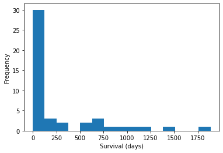

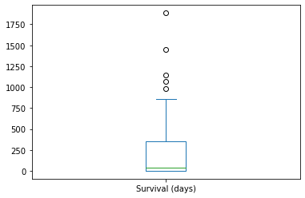

```
count      46.000000
mean      270.304348
std       447.269338
min         0.000000
25%         1.250000
50%        33.000000
75%       347.500000
max      1886.000000
Name: Survival (days), dtype: float64
```

```python
df['Survival (days)'].plot(kind='hist', bins=15)
plt.xlabel('Survival (days)')
plt.show()
df['Survival (days)'].plot(kind='box')
plt.show()
df['Survival (days)'].describe()
```

We can see that sadly, most cats in the dataset survived only a very short amount of time -- half of the cats survived only one month or less, and the majority (75%) survived less than one year. However, there's clearly a strong right skew in this distribution with many outliers who had high survival time values, including one cat who survived over 5 years (and who was still alive at the conclusion of the study). In the next sections, we will perform exploratory data analysis to identify features that are correlated or anti-correlated with survival times.

### 2.3 "Naive" exploratory data analysis

In this section we will perform a kind of "naive" analysis, and plot the quantitative and categorical features against the raw survival times given in the "Survival (days)" column. I call this analysis "naive" because many of the cats in the dataset were still alive at the conclusion of the original study, so their true survival time could potentially be much higher than the number of days indicated in the "Survival (days)" column. Nevertheless, this analysis should help reveal some general patterns and correlations present in the data.

#### 2.3.1 Creatine

High creatine levels have a negative association with survival times. Although we can see a couple of outliers, in general cats who survived for any significant amount of time (longer than 6 months) had lower creatine levels at 48 hours (generally less than 6). High creatine levels above 6 generally had low survival times.

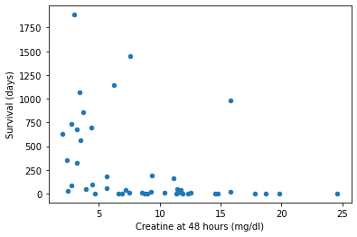

```python
df[['Creatine at 48 hours (mg/dl)', 'Survival (days)']].plot(kind='scatter', x='Creatine at 48 hours (mg/dl)', y='Survival (days)')
plt.show()
```

#### 2.3.2 Body weight

There seems to be a slightly negative association betwen body weight and survival times, with the majority of the long-lived (survival > 500 days) cats weighing less than 4kg.

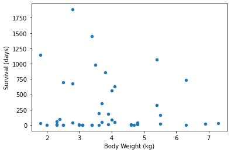

```python
df[['Body Weight (kg)', 'Survival (days)']].plot(kind='scatter', x='Body Weight (kg)', y='Survival (days)')
plt.show()
```

#### 2.3.3 Case severity score

Surprisingly, the plots do not seem to reveal a very salient association between case severity scores (CSS) and survival times. Higher CSS of 6 or 7 seems to have lower average survival times, but otherwise no linear/monotonic association seems to be present. CSS of both 1 and 4 seem to have slightly higher average survival times than the other scores.

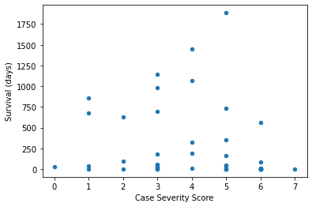

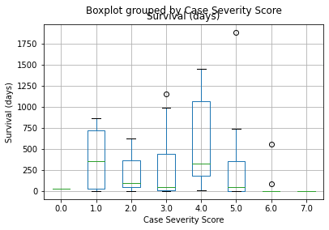

```python
df[['Case Severity Score', 'Survival (days)']].plot(kind='scatter', x='Case Severity Score', y='Survival (days)')
plt.show()
df.boxplot(column='Survival (days)',by='Case Severity Score')
plt.ylabel('Survival (days)')
plt.show()
```

#### 2.3.4 Age

There seems to be a negative association between age and survival times. The majority of cats who survived past one year were under age 12.

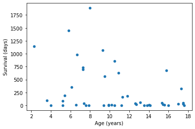

```python
df[['Age (years)', 'Survival (days)']].plot(kind='scatter', x='Age (years)', y='Survival (days)')
plt.show()
```

#### 2.3.5 Sex

There is a very strong association between sex and survival times, with female cats surviving significantly longer (mean: 407 days, median: 161 days) than male cats (mean: 107 days, median: 9 days). There are also roughly equal numbers of male and female cats in the dataset, so this association is not due to an artifact of small sample size.

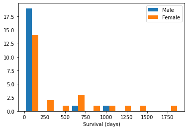

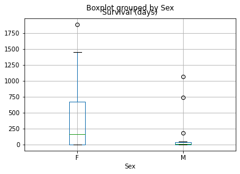

| Sex | count | mean | std | min | 25% | 50% | 75% | max |
| --- | --- | --- | --- | --- | --- | --- | --- | --- |
| F | 25.0 | 407.440000 | 520.035101 | 0.0 | 4.0 | 161.0 | 672.0 | 1886.0 |
| M | 21.0 | 107.047619 | 272.204422 | 0.0 | 1.0 | 9.0 | 39.0 | 1065.0 |

```python
m = df.loc[df['Sex'] == 'M', 'Survival (days)']
f = df.loc[df['Sex'] == 'F', 'Survival (days)']
plt.hist([m,f], label=['Male', 'Female'])
plt.xlabel('Survival (days)')
plt.legend()
plt.show()

df.boxplot(column='Survival (days)',by='Sex')
plt.show()

df.groupby('Sex')['Survival (days)'].describe()
```

#### 2.3.6 Small kidneys

Surprisingly, cats with one small kidney seem to have higher average survival times than cats with either no small kidneys or two small kidneys.

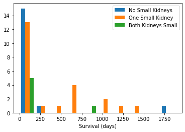

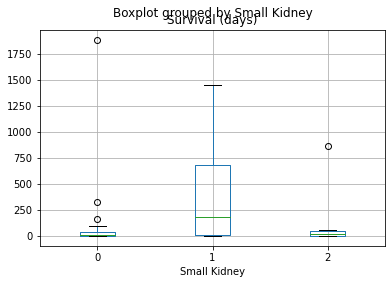

| Small Kidney | count | mean | std | min | 25% | 50% | 75% | max |
| --- | --- | --- | --- | --- | --- | --- | --- | --- |
| 0 | 17.0 | 152.764706 | 454.306687 | 0.0 | 1.0 | 7.0 | 39.00 | 1886.0 |
| 1 | 23.0 | 386.565217 | 451.364580 | 0.0 | 10.5 | 183.0 | 686.00 | 1448.0 |
| 2 | 6.0 | 157.666667 | 345.253916 | 0.0 | 0.0 | 16.0 | 47.75 | 861.0 |

```python
a = df.loc[df['Small Kidney'] == 0, 'Survival (days)']
b = df.loc[df['Small Kidney'] == 1, 'Survival (days)']
c = df.loc[df['Small Kidney'] == 2, 'Survival (days)']
plt.hist([a,b,c], label=['No Small Kidneys', 'One Small Kidney', 'Both Kidneys Small'])
plt.xlabel('Survival (days)')
plt.legend()
plt.show()

df.boxplot(column='Survival (days)',by='Small Kidney')
plt.show()

df.groupby('Small Kidney')['Survival (days)'].describe()
```

#### 2.3.7 Nephroliths

Confusingly, cats with nephroliths (kidney stones) have a higher median survival time, but lower mean survival time. As we will see in analyses in the future sections, cats who have kidney stones are *more* likely to survive to 100 days, but *less* likely to survive to 500 days. This phenomenon of increased short-term survival rates but decreased long-term survival rates may explain the difference between the mean and median values.

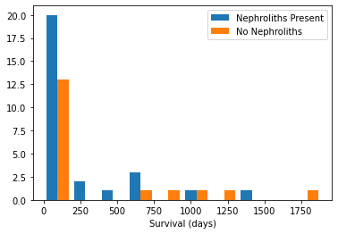

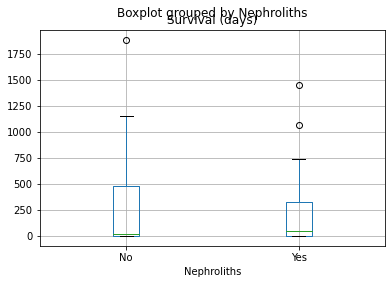

| Nephroliths | count | mean | std | min | 25% | 50% | 75% | max |
| --- | --- | --- | --- | --- | --- | --- | --- | --- |
| No | 18.0 | 315.555556 | 552.708116 | 0.0 | 1.75 | 15.5 | 482.75 | 1886.0 |
| Yes | 28.0 | 241.214286 | 372.599711 | 0.0 | 1.75 | 46.0 | 330.50 | 1448.0 |

```python
has_nephroliths = df.loc[df['Nephroliths'] == 'Yes', 'Survival (days)']
no_nephroliths = df.loc[df['Nephroliths'] == 'No', 'Survival (days)']
plt.hist([has_nephroliths,no_nephroliths], label=['Nephroliths Present', 'No Nephroliths'])
plt.xlabel('Survival (days)')
plt.legend()
plt.show()

df.boxplot(column='Survival (days)',by='Nephroliths')
plt.show()

df.groupby('Nephroliths')['Survival (days)'].describe()
```

#### 2.3.8 Aetiology

For the aetiology feature, the dataset shows only 3 different values: "Pyelonephritis" (kidney infection), "NaN" (unknown), and "Cardiorenal syndrome". However, only one cat had cardiorenal syndrome, so this category is not really useful. To do exploratory analysis on this feature, we will first replace the "NaN" and "Cardiorenal syndrome" values with "Unknown or Other Aetiology".

We can see that cats with pyelonephritis on average significantly outlived cats with unknown or other aetiology.

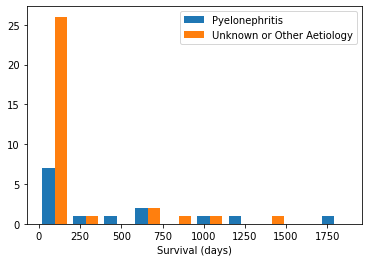

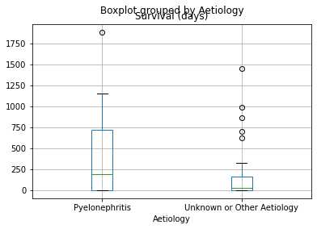

| Aetiology | count | mean | std | min | 25% | 50% | 75% | max |
| --- | --- | --- | --- | --- | --- | --- | --- | --- |
| Pyelonephritis | 14.0 | 462.642857 | 585.094944 | 0.0 | 2.50 | 194.0 | 721.5 | 1886.0 |
| Unknown or Other Aetiology | 32.0 | 186.156250 | 350.454462 | 0.0 | 1.75 | 30.0 | 166.5 | 1448.0 |

```python
pyelonephritis = df.loc[df['Aetiology'] == 'Pyelonephritis', 'Survival (days)']
not_pyelonephritis = df.loc[df['Aetiology'] != 'Pyelonephritis', 'Survival (days)']
plt.hist([pyelonephritis,not_pyelonephritis], label=['Pyelonephritis', 'Unknown or Other Aetiology'])
plt.xlabel('Survival (days)')
plt.legend()
plt.show()

df['Aetiology'] = df['Aetiology'].replace({None:'Unknown or Other Aetiology', 'Cardiorenal syndrome':'Unknown or Other Aetiology'})
df.boxplot(column='Survival (days)',by='Aetiology')
plt.show()

df.groupby('Aetiology')['Survival (days)'].describe()
```

#### 2.3.9 Breed

For the breed feature, we can see from the dataset that only a small number of cats were breeds other than domestic shorthair (DSH) -- only 6 out of 46 cats were other breeds. Their individual breed categories are therefore not really useful, so before we do the data analysis we will replace these values with "Other Breed".

The DSH and breed cats have similar median survival times (30 days vs 38 days), however the mean survival time for DSH cats (282 days) is much higher than the mean survival time for the breed cats (191 days). This indicates that the survival time distribution for DSH cats is much more right skewed, and there are many more long-lived DSH cats than breed cats, as we can see from the histogram plot.

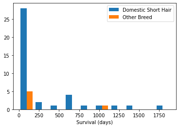

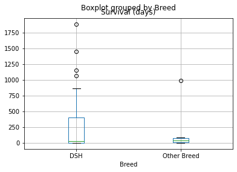

| Breed | count | mean | std | min | 25% | 50% | 75% | max |
| --- | --- | --- | --- | --- | --- | --- | --- | --- |
| DSH | 40.0 | 282.250000 | 458.444849 | 0.0 | 1.75 | 30.0 | 407.0 | 1886.0 |
| Other Breed | 6.0 | 190.666667 | 390.329946 | 0.0 | 8.75 | 38.0 | 72.5 | 985.0 |

```python
dsh = df.loc[df['Breed'] == 'DSH', 'Survival (days)']
other_breed = df.loc[df['Breed'] != 'DSH', 'Survival (days)']
plt.hist([dsh,other_breed], label=['Domestic Short Hair', 'Other Breed'])
plt.xlabel('Survival (days)')
plt.legend()

df['Breed'] = df['Breed'].replace({'Siamese':'Other Breed', 'Birman':'Other Breed', 'Ragdoll':'Other Breed'})
df.boxplot(column='Survival (days)',by='Breed')
plt.show()

df.groupby('Breed')['Survival (days)'].describe()
```

#### 2.3.10 Spontaneous feeding at 48 hours

Cats who exhibited spontaneous feeding at 48 hours were significantly longer-lived (mean: 353 days, median: 53 days) than the cats who were not eating at that time (mean: 98 days, median: 0 days). We can also see from the histogram plot that nearly all cats who survived past 6 months were eating at 48 hours post-hospitalization.

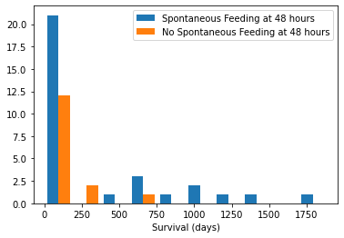

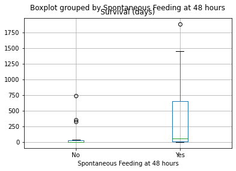

| Spontaneous Feeding at 48 hours | count | mean | std | min | 25% | 50% | 75% | max |
| --- | --- | --- | --- | --- | --- | --- | --- | --- |
| No | 15.0 | 98.400000 | 212.367875 | 0.0 | 0.0 | 0.0 | 27.0 | 738.0 |
| Yes | 31.0 | 353.483871 | 507.053309 | 0.0 | 10.5 | 53.0 | 649.5 | 1886.0 |

```python
spf = df.loc[df['Spontaneous Feeding at 48 hours'] == 'Yes', 'Survival (days)']
no_spf = df.loc[df['Spontaneous Feeding at 48 hours'] == 'No', 'Survival (days)']
plt.hist([spf,no_spf], label=['Spontaneous Feeding at 48 hours', 'No Spontaneous Feeding at 48 hours'])
plt.xlabel('Survival (days)')
plt.legend()
plt.show()

df.boxplot(column='Survival (days)',by='Spontaneous Feeding at 48 hours')
plt.show()

df.groupby('Spontaneous Feeding at 48 hours')['Survival (days)'].describe()
```

#### 2.3.11 Neutered

The dataset shows that only 3 cats out of 46 were not neutered. A sample this small is likely not useful for categorization or performing data analysis on, so we will ignore this feature.

#### 2.3.12 Summary

After performing this "naive" analysis, we saw some general patterns.

For the quantitative features:

- Higher values for **creatine, body weight, and age** were all associated with **lower survival times**

For the categorical features:

- **Females, cats with pyelonephritis, domestic short hair cats, and cats who fed spontaneously at 48 hours** were **longer-lived** than cats not in those categories
- Presence of nephroliths had a more complicated relationship with survival times: **cats with kidney stones had higher median survival times but lower mean survival times**
- No monotonic relationship between case severity score and survival times could be discerned from the data

### 2.4 Exploratory data analysis, with categorization by 100 and 500 days survival

Although the previous "naive" analysis revealed some general patterns, its reliability is limited because many of the longer-lived cats were still alive at the conclusion of the original study, and so many of the raw values obtained from "Survival (days)" column are likely to be inaccurate and possibly significantly lower than true survival times. In order to do data analysis and build an ML model with more reliability, we will do some pre-processing on the data and categorize the cats by survival to 100 days and 500 days, and then we will perform exploratory data analysis on these categories. The thresholds of 100 days and 500 days were chosen because these values seemed to be natural breaks in the data upon visual inspection of the survival times histogram plot.

#### 2.4.1 Data pre-processing

We will add two columns to our dataset called 'Survived 100 days' and 'Survived 500 days' whose values are 'Yes', 'No', or 'NaN' (if unknown). Although we know the values for survival at 100 days for all cats in the dataset, we're careful to handle the case where survival at 500 days is unknown because the cat was still alive at the conclusion of the original study.

```python
def survived_x_days(row, num_days):
    if row['Survival (days)'] < num_days and row['Still alive at conclusion of study?'] == 'No':
        return 'No'
    elif row['Survival (days)'] >= num_days:
        return 'Yes'
    else:
        return float('NaN')

def survived_100_days(row):
    return survived_x_days(row, 100)

def survived_500_days(row):
    return survived_x_days(row, 500)

df['Survived 100 days'] = df.apply (lambda row: survived_100_days(row), axis=1)
df['Survived 500 days'] = df.apply (lambda row: survived_500_days(row), axis=1)

df = df.drop(columns=['Case','Neutered','Survival (days)','Still alive at conclusion of study?'])
```

After doing the categorization by 100 days survived and 500 days survived, we will drop the columns "Survival (days)" and "Still alive at conclusion of study?" since they will not be used in subsequent analyses. In addition, we will drop the columns "Case" and "Neutered" since they are not useful to our analysis.

Let's take a look at our new pre-processed data:

```python
df
```

|  | Breed | Sex | Age (years) | Body Weight (kg) | Case Severity Score | Small Kidney | Nephroliths | Creatine at 48 hours (mg/dl) | Spontaneous Feeding at 48 hours | Aetiology | Survived 100 days | Survived 500 days |
| --- | --- | --- | --- | --- | --- | --- | --- | --- | --- | --- | --- | --- |
| 0 | DSH | M | 9.9 | 3.1 | 5.0 | 0 | No | 12.35 | No | Unknown or Other Aetiology | No | No |
| 1 | DSH | M | 9.4 | 4.7 | 3.0 | 2 | Yes | 24.59 | Yes | Unknown or Other Aetiology | No | No |
| 2 | DSH | F | 7.9 | 2.0 | 7.0 | 2 | Yes | 11.84 | No | Unknown or Other Aetiology | No | No |
| 3 | DSH | F | 7.6 | 3.4 | 2.0 | 1 | Yes | 14.74 | No | Pyelonephritis | No | No |
| 4 | Other Breed | F | 16.0 | 3.0 | 6.0 | 1 | No | 19.78 | No | Pyelonephritis | No | No |
| 5 | DSH | F | 13.5 | 2.5 | 6.0 | 0 | Yes | 11.33 | Yes | Unknown or Other Aetiology | No | No |
| 6 | DSH | M | 4.0 | 2.3 | 6.0 | 2 | Yes | 8.77 | No | Unknown or Other Aetiology | No | No |
| 7 | DSH | M | 5.2 | 3.1 | 6.0 | 0 | No | 14.54 | No | Unknown or Other Aetiology | No | No |
| 8 | DSH | F | 17.6 | 2.5 | 6.0 | 0 | No | 8.97 | No | Pyelonephritis | No | No |
| 9 | DSH | M | 10.5 | 6.3 | 5.0 | 1 | Yes | 17.78 | No | Unknown or Other Aetiology | No | No |
| 10 | Other Breed | M | 14.1 | 3.6 | 3.0 | 1 | No | 6.93 | Yes | Unknown or Other Aetiology | No | No |
| 11 | DSH | F | NaN | 3.1 | 1.0 | 0 | Yes | 6.60 | Yes | Pyelonephritis | No | No |
| 12 | DSH | M | 13.8 | 3.4 | 6.0 | 0 | Yes | 18.68 | No | Unknown or Other Aetiology | No | No |
| 13 | DSH | M | 11.2 | 4.6 | 5.0 | 0 | Yes | 4.69 | Yes | Unknown or Other Aetiology | No | No |
| 14 | DSH | F | 15.6 | 3.9 | 6.0 | 1 | No | 12.57 | No | Unknown or Other Aetiology | No | No |
| 15 | DSH | M | 14.0 | 4.6 | 6.0 | 0 | No | 8.53 | Yes | Unknown or Other Aetiology | No | No |
| 16 | DSH | M | 10.2 | 4.8 | 3.0 | 0 | No | 10.40 | Yes | Pyelonephritis | No | No |
| 17 | DSH | M | 6.6 | 3.0 | NaN | 1 | Yes | 7.47 | Yes | Unknown or Other Aetiology | No | No |
| 18 | DSH | F | 9.9 | 2.3 | 4.0 | 1 | No | 11.51 | Yes | Pyelonephritis | No | No |
| 19 | DSH | M | 15.4 | 6.9 | 3.0 | 0 | No | 9.27 | Yes | Unknown or Other Aetiology | No | No |
| 20 | DSH | M | 12.7 | 5.5 | NaN | 1 | Yes | 15.83 | No | Unknown or Other Aetiology | No | No |
| 21 | DSH | M | 17.0 | 7.3 | 0.0 | 0 | Yes | 2.47 | Yes | Unknown or Other Aetiology | No | No |
| 22 | Other Breed | F | 17.5 | 1.8 | 3.0 | 2 | No | NaN | Yes | Pyelonephritis | No | No |
| 23 | DSH | M | 7.4 | 2.8 | 5.0 | 0 | Yes | 7.20 | No | Unknown or Other Aetiology | No | No |
| 24 | DSH | M | 12.6 | 4.8 | 1.0 | 0 | Yes | 11.76 | Yes | Unknown or Other Aetiology | No | No |
| 25 | Other Breed | M | 15.3 | 3.7 | 3.0 | 1 | No | 3.93 | Yes | Unknown or Other Aetiology | No | No |
| 26 | DSH | M | 17.5 | 4.1 | 5.0 | 1 | No | 11.46 | Yes | Unknown or Other Aetiology | No | No |
| 27 | DSH | F | 13.1 | 2.3 | 3.0 | 2 | Yes | 5.67 | Yes | Unknown or Other Aetiology | No | No |
| 28 | Other Breed | F | 5.2 | 4.0 | 6.0 | 1 | Yes | 2.72 | Yes | Unknown or Other Aetiology | No | No |
| 29 | DSH | F | 3.6 | 2.4 | 2.0 | 0 | Yes | 4.47 | Yes | Unknown or Other Aetiology | No | No |
| 30 | DSH | F | 11.3 | 5.5 | 5.0 | 0 | Yes | 11.15 | Yes | Unknown or Other Aetiology | Yes | No |
| 31 | DSH | F | 11.8 | 3.9 | 3.0 | 1 | Yes | 5.61 | Yes | Unknown or Other Aetiology | Yes | No |
| 32 | DSH | M | 5.4 | 3.6 | 4.0 | 1 | Yes | 9.33 | Yes | Unknown or Other Aetiology | Yes | No |
| 33 | DSH | F | 17.3 | 5.4 | 4.0 | 0 | Yes | 3.20 | No | Unknown or Other Aetiology | Yes | No |
| 34 | DSH | F | 6.1 | 3.7 | 5.0 | 1 | Yes | 2.37 | No | Pyelonephritis | Yes | NaN |
| 35 | DSH | F | 9.5 | 4.0 | 6.0 | 1 | Yes | 3.45 | Yes | Pyelonephritis | Yes | Yes |
| 36 | DSH | F | 10.9 | 4.1 | 2.0 | 1 | No | 1.99 | Yes | Unknown or Other Aetiology | Yes | Yes |
| 37 | DSH | F | 15.8 | 2.8 | 1.0 | 1 | Yes | 3.16 | Yes | Pyelonephritis | Yes | Yes |
| 38 | DSH | F | 7.3 | 2.5 | 3.0 | 1 | Yes | 4.40 | Yes | Unknown or Other Aetiology | Yes | Yes |
| 39 | DSH | M | 7.3 | 6.3 | 5.0 | 1 | Yes | 2.76 | No | Pyelonephritis | Yes | Yes |
| 40 | DSH | F | 10.5 | 3.8 | 1.0 | 2 | No | 3.68 | Yes | Unknown or Other Aetiology | Yes | Yes |
| 41 | Other Breed | F | 6.7 | 3.5 | 3.0 | 1 | No | 15.82 | Yes | Unknown or Other Aetiology | Yes | Yes |
| 42 | DSH | M | 9.3 | 5.4 | 4.0 | 1 | Yes | 3.40 | Yes | Pyelonephritis | Yes | Yes |
| 43 | DSH | F | 2.3 | 1.8 | 3.0 | 1 | No | 6.20 | Yes | Pyelonephritis | Yes | Yes |
| 44 | DSH | F | 5.8 | 3.4 | 4.0 | 1 | Yes | 7.58 | Yes | Unknown or Other Aetiology | Yes | Yes |
| 45 | DSH | F | 8.0 | 2.8 | 5.0 | 0 | No | 2.97 | Yes | Pyelonephritis | Yes | Yes |

#### 2.4.2 Overview of survival per category

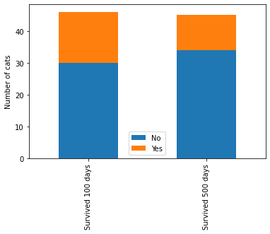

|  | Survived 100 days | Survived 500 days |
| --- | --- | --- |
| No | 30 | 34 |
| Yes | 16 | 11 |

```python
df2 = pd.DataFrame(df['Survived 100 days'].value_counts())
df2['Survived 500 days'] = pd.DataFrame(df['Survived 500 days'].value_counts())
df2.transpose().plot.bar(stacked=True)
plt.ylabel('Number of cats')
plt.show()
df2
```

We can see that 16 out of 46 cats (35%) survived to 100 days after hospitalization, and 11 out of 45 cats (25%) survived to 500 days. Note that the total count is different for 500 days survival (only 45 data points vs 46 for 100 days survival) because there is one cat for whom we don't know the 500 days survival value, because they survived to 356 days but was still alive at the conclusion of the original study.

Next we'll plot each feature categorized by 100 days and 500 days survival values.

First we create some helper functions to help plot the histogram and box plot comparisons for each feature.

```python
from pandas.api.types import is_numeric_dtype

def plot_survival_comparison_for_num_days(variable_name, num_days):
    num_days_str = ' ' + str(num_days) + ' days'
    survival_category_title = 'Survived' + num_days_str
    survived = df.loc[df[survival_category_title] == 'Yes', variable_name]
    not_survived = df.loc[df[survival_category_title] == 'No', variable_name]
    plt.hist([survived, not_survived], label=[survival_category_title, 'Did not survive' + num_days_str])
    plt.xlabel(variable_name)
    plt.ylabel('Number of cats')
    plt.legend()
    plt.show()

    if is_numeric_dtype(df[variable_name]):
        df.boxplot(column=variable_name,by=survival_category_title)
        plt.ylabel(variable_name)
        plt.show()
        print(df.groupby(survival_category_title)[variable_name].describe())
    else :
        print(df.groupby(variable_name)[survival_category_title].value_counts())

def plot_survival_comparison(variable_name):
    num_days = [100, 500]
    for y in num_days:
        plot_survival_comparison_for_num_days(variable_name, y)
```

#### 2.4.3 Age

We can see that increasing age is negatively associated with survival at 100 and 500 days. The average age of cats who survived at 500 days (mean: 8.5 years) was lower than the average age of cats who survived to 100 days (mean: 9.1 years) and both were lower than the average age of cats who did not survive (mean: 11.5 years, for both categories). While a minority of cats over age 12 survived to 100 days, only one cat over age 12 survived to 500 days.

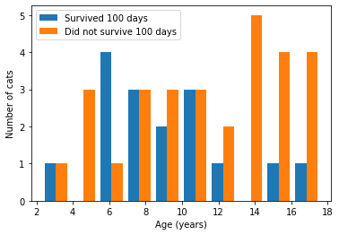

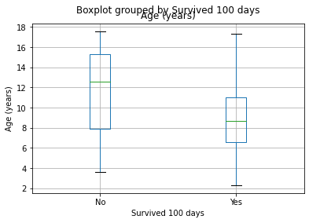

```
                   count       mean       std  min   25%    50%   75%   max
Survived 100 days
No                  29.0  11.527586  4.280345  3.6  7.90  12.60  15.3  17.6
Yes                 16.0   9.081250  3.855078  2.3  6.55   8.65  11.0  17.3
```

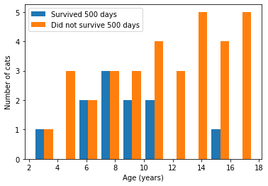

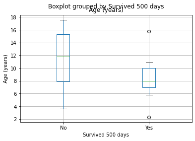

```
                   count       mean       std  min  25%   50%   75%   max
Survived 500 days
No                  33.0  11.518182  4.271962  3.6  7.9  11.8  15.3  17.6
Yes                 11.0   8.490909  3.417442  2.3  7.0   8.0  10.0  15.8
```

```python
plot_survival_comparison('Age (years)')
```

#### 2.4.4 Body weight

Confusingly, we see a slightly higher average (mean and median) body weight among cats who survived to 100 days versus those who did not survive, but a slightly lower average body weight among cats who survived to 500 days versus those who did not survive. The differences are small, and T-test results show the differences are not statistically significant.

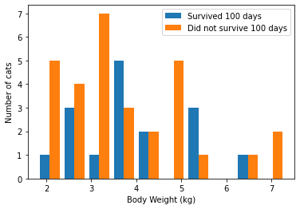

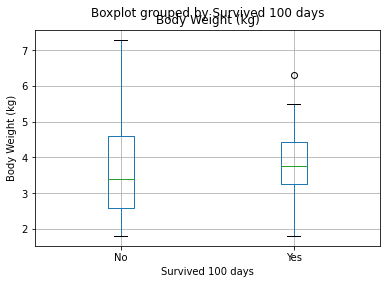

```
                   count      mean       std  min    25%   50%    75%  max
Survived 100 days
No                  30.0  3.726667  1.420523  1.8  2.575  3.40  4.600  7.3
Yes                 16.0  3.906250  1.216809  1.8  3.250  3.75  4.425  6.3
```

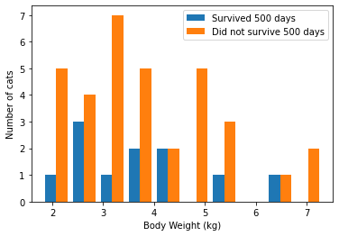

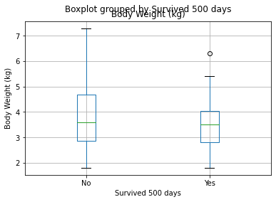

```
                   count      mean       std  min   25%  50%    75%  max
Survived 500 days
No                  34.0  3.829412  1.394259  1.8  2.85  3.6  4.675  7.3
Yes                 11.0  3.672727  1.292355  1.8  2.80  3.5  4.050  6.3
```

```python
plot_survival_comparison('Body Weight (kg)')
```

T-tests for statistical significance:

```python
from scipy.stats import ttest_ind
print('T-test for statistical significance: body weight values categorized by survival at 100 days:')
print(ttest_ind(df[df['Survived 100 days'] == 'No']['Body Weight (kg)'], df[df['Survived 100 days'] == 'Yes']['Body Weight (kg)']))
print('\nT-test for statistical significance: body weight values categorized by survival at 500 days:')
print(ttest_ind(df[df['Survived 500 days'] == 'No']['Body Weight (kg)'], df[df['Survived 500 days'] == 'Yes']['Body Weight (kg)']))
```

```
T-test for statistical significance: body weight values categorized by survival at 100 days:
Ttest_indResult(statistic=-0.4282741490824837, pvalue=0.6705407841262447)

T-test for statistical significance: body weight values categorized by survival at 500 days:
Ttest_indResult(statistic=0.3294149542100517, pvalue=0.7434413378183151)
```

#### 2.4.5 Case severity score

Case severity score seems to be negatively associated with survival at 100 and 500 days. The average case severity scores among cats who survived to 500 days (mean: 3.4) were lower than average scores for cats who survived to 100 days (mean: 3.6), both of which are lower than average scores among cats who did not survive (mean: 4.2, for both categories).

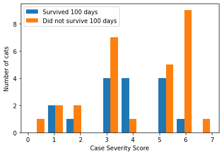

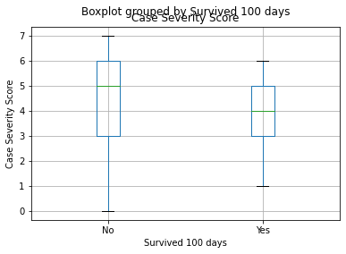

```
                   count      mean       std  min  25%  50%  75%  max
Survived 100 days
No                  28.0  4.178571  1.906200  0.0  3.0  5.0  6.0  7.0
Yes                 16.0  3.625000  1.454877  1.0  3.0  4.0  5.0  6.0
```

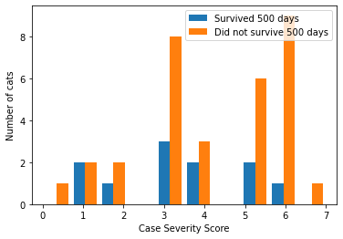

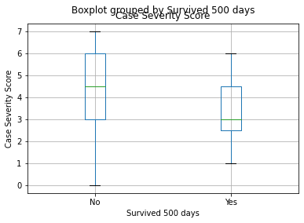

```
                   count      mean       std  min  25%  50%  75%  max
Survived 500 days
No                  32.0  4.156250  1.798016  0.0  3.0  4.5  6.0  7.0
Yes                 11.0  3.363636  1.629278  1.0  2.5  3.0  4.5  6.0
```

```python
plot_survival_comparison('Case Severity Score')
```

#### 2.4.6 Creatine

We see a strong pattern of high creatine levels being negatively associated with survival at 100 and 500 days. The average creatine level among cats who survived to 500 days (mean: 5.0 mg/dl) was lower than for cats who survived to 100 days (mean: 5.4 mg/dl), both of which are significantly lower than average scores among cats who did not survive in those categories (10.2 mg/dl and 10.6 mg/dl).

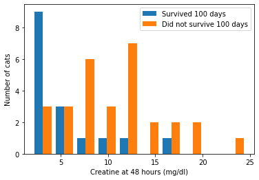

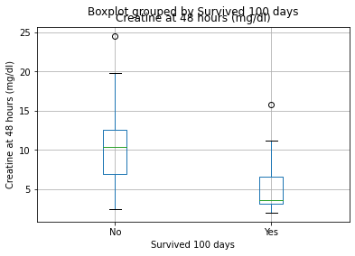

```
                   count       mean       std   min     25%     50%     75%  \
Survived 100 days
No                  29.0  10.581034  5.349164  2.47  6.9300  10.400  12.570
Yes                 16.0   5.441875  3.810461  1.99  3.1125   3.565   6.545

                     max
Survived 100 days
No                 24.59
Yes                15.82
```

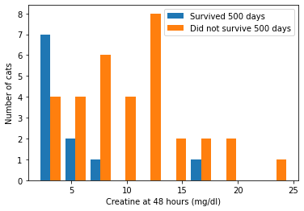

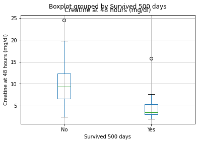

```
                   count       mean       std   min    25%   50%    75%    max
Survived 500 days
No                  33.0  10.186061  5.235430  2.47  6.600  9.33  12.35  24.59
Yes                 11.0   5.037273  3.921768  1.99  3.065  3.45   5.30  15.82
```

```python
plot_survival_comparison('Creatine at 48 hours (mg/dl)')
```

#### 2.4.7 Sex

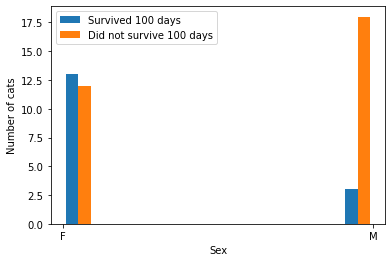

```
Sex  Survived 100 days
F    Yes                  13
     No                   12
M    No                   18
     Yes                   3
Name: Survived 100 days, dtype: int64
```

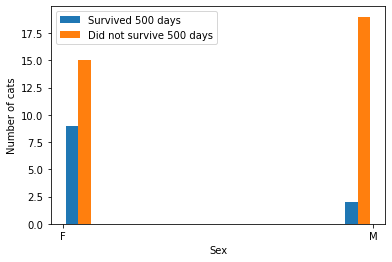

```
Sex  Survived 500 days
F    No                   15
     Yes                   9
M    No                   19
     Yes                   2
Name: Survived 500 days, dtype: int64
```

```python
plot_survival_comparison('Sex')
```

#### 2.4.8 Breed

We can see that domestic short-hair (DSH) cats have a higher rate of survival to 100 and 500 days than breed cats. While 38% of DSH cats survived to 100 days, and 26% of DSH cats survived to 500 days, only one breed cat in the dataset (1/6 or 17%) survived past 100 days.

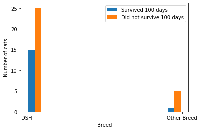

```
Breed        Survived 100 days
DSH          No                   25
             Yes                  15
Other Breed  No                    5
             Yes                   1
Name: Survived 100 days, dtype: int64
```

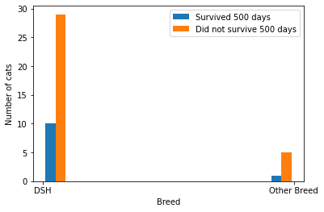

```
Breed        Survived 500 days
DSH          No                   29
             Yes                  10
Other Breed  No                    5
             Yes                   1
Name: Survived 500 days, dtype: int64
```

```python
plot_survival_comparison('Breed')
```

#### 2.4.9 Small kidney

Surprisingly, having one small kidney seems to be associated with higher survival rates at 100 and 500 days, than either having no small kidneys or two small kidneys.

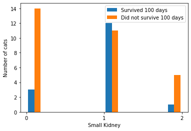

```
Small Kidney  Survived 100 days
0             No                   14
              Yes                   3
1             Yes                  12
              No                   11
2             No                    5
              Yes                   1
Name: Survived 100 days, dtype: int64
```

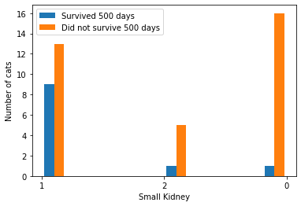

```
Small Kidney  Survived 500 days
0             No                   16
              Yes                   1
1             No                   13
              Yes                   9
2             No                    5
              Yes                   1
Name: Survived 500 days, dtype: int64
```

```python
df['Small Kidney'] = df['Small Kidney'].astype(str)
plot_survival_comparison('Small Kidney')
```

#### 2.4.10 Nephroliths

Surprisingly, the presence of nephroliths (kidney stones) was associated with higher survival rates at 100 days -- 39% (11/28) of cats who had kidney stones survived at 100 days, whereas only 28% (5/18) of cats who did not have kidney stones survived to 100 days. Confusingly though, nephroliths were also negatively associated with survival at 500 days -- 22% (6/27) of cats who had kidney stones survived to 500 days, whereas 28% (5/18) of cats who did not have kidney stones survived to 500 days.

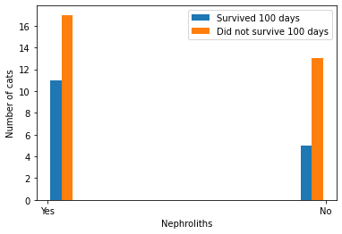

```
Nephroliths  Survived 100 days
No           No                   13
             Yes                   5
Yes          No                   17
             Yes                  11
Name: Survived 100 days, dtype: int64
```

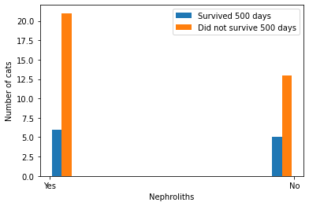

```
Nephroliths  Survived 500 days
No           No                   13
             Yes                   5
Yes          No                   21
             Yes                   6
Name: Survived 500 days, dtype: int64
```

```python
plot_survival_comparison('Nephroliths')
```

#### 2.4.11 Spontaneous feeding at 48 hours

Spontaneous feeding at 48 hours is associated with significantly higher survival rates at 100 and 500 days, with the effect being more pronounced for survival at 500 days. 42% (13/31) of cats who ate spontaneously survived to 100 days, whereas only 20% (3/15) of cats who did not eat survived to 100 days. At 500 days, 32% (10/31) of cats who ate spontaneously survived, whereas only 7% (1/14) of cats who did not eat survived.

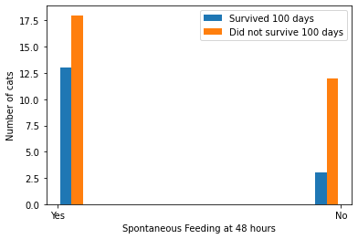

```
Spontaneous Feeding at 48 hours  Survived 100 days
No                               No                   12
                                 Yes                   3
Yes                              No                   18
                                 Yes                  13
Name: Survived 100 days, dtype: int64
```

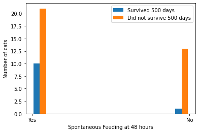

```
Spontaneous Feeding at 48 hours  Survived 500 days
No                               No                   13
                                 Yes                   1
Yes                              No                   21
                                 Yes                  10
Name: Survived 500 days, dtype: int64
```

```python
plot_survival_comparison('Spontaneous Feeding at 48 hours')
```

#### 2.4.12 Aetiology

Cats with pyelonephritis (kidney infection) had significantly higher survival rates at 100 and 500 days than cats with unknown or other aetiologies, with the effect being more pronounced for survival at 500 days. 50% (7/14) of cats with kidney infection survived to 100 days, whereas only 28% (9/32) of cats with unknown or other aetiologies survived to 100 days. At 500 days, 46% (6/13) of cats with kidney infection survived, whereas only 16% (5/32) of cats with unknown or other aetiologies survived.

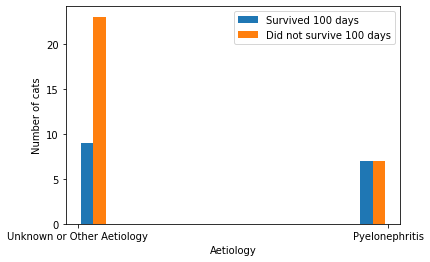

```
Aetiology                   Survived 100 days
Pyelonephritis              No                    7
                            Yes                   7
Unknown or Other Aetiology  No                   23
                            Yes                   9
Name: Survived 100 days, dtype: int64
```

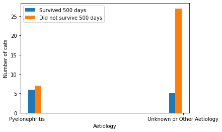

```
Aetiology                   Survived 500 days
Pyelonephritis              No                    7
                            Yes                   6
Unknown or Other Aetiology  No                   27
                            Yes                   5
Name: Survived 500 days, dtype: int64
```

```python
plot_survival_comparison('Aetiology')
```

#### 2.4.13 Summary

We gleaned some important insights into survival patterns from this categorical comparison analysis.

For the quantitative features:

- Higher values for **age, case severity score, and creatine levels** were associated with **significantly lower survival rates at 100 days, with the effect being even more pronounced at 500 days**
- Average body weight did not differ in a statistically significant way between those who survived and those who did not survive to 100 and 500 days

For the categorical features:

- **Cats with pyelonephritis and those who fed spontaneously at 48 hours** had **significantly higher survival rates at 100 days, with the effect being even more pronounced at 500 days**, than cats not in those categories
- **Females, domestic short-hairs, and cats with one small kidney** had **higher survival rates at 100 and 500 days** than cats not in those categories
- Presence of nephroliths had a more complicated relationship with survival times: **kidney stones were associated with higher survival rates at 100 days but lower survival rates at 500 days**

## 3. Building an ML classifier for predicting survival at 100 days and 500 days

We will now use the features we've analyzed to build classifiers for predicting survival.

### 3.1 Choosing a classifier

To start, we will choose the histogram gradient boosting classifier, which is an ensemble learning algorithm based on boosting weak decision tree learners. We choose this classifier because of its native support for both quantitative and categorical features, as well as its native support for handling missing values in the dataset (we have a very small dataset with quite a few missing values, and would like to avoid excluding rows).

### 3.2 Data pre-processing

First, we need to do some data pre-processing. We encode the values for all the categorical features, transforming text values into integers representing each category. Additionally, we create new dataframes separating the target columns from the feature columns, and drop rows with unknown target values.

```python
# Categorical feature encodings
df['Small Kidney'] = df['Small Kidney'].astype(int)
df['Sex'] = df['Sex'].replace({'M':1, "F":0})
df['Breed'] = df['Breed'].replace({'DSH':0, 'Other Breed':1})
df['Nephroliths'] = df['Nephroliths'].replace({'Yes':1, 'No':0})
df['Spontaneous Feeding at 48 hours'] = df['Spontaneous Feeding at 48 hours'].replace({'Yes':1, 'No':0})
df['Aetiology'] = df['Aetiology'].replace({'Pyelonephritis':1, 'Unknown or Other Aetiology':0})
df['Survived 100 days'] = df['Survived 100 days'].replace({'Yes':1, 'No':0})
df['Survived 500 days'] = df['Survived 500 days'].replace({'Yes':1, 'No':0})

# Drop rows without target value, and separate target columns from feature columns
df_500_days_classifier = df[df['Survived 500 days'].notnull()]
features_500_days = df_500_days_classifier.drop(['Survived 500 days', 'Survived 100 days'], axis=1)
target_500_days = df_500_days_classifier['Survived 500 days']
features_100_days = df.drop(['Survived 500 days', 'Survived 100 days'], axis=1)
target_100_days = df['Survived 100 days']
```

### 3.3 First attempt: training a “naive” model

Now we're ready to train and test the histogram gradient boosting classifier. We'll do a train-test split, train the model, predict target values with the test data, and evaluate performance on true target values. Let's try it out with predicting survival at 500 days:

```python
from sklearn.ensemble import HistGradientBoostingClassifier
from sklearn.model_selection import train_test_split
import sklearn.metrics

X_train, X_test, y_train, y_test = train_test_split(features_500_days, target_500_days, test_size=0.2, random_state=1)
model = HistGradientBoostingClassifier().fit(X_train, y_train)
y_pred = model.predict(X_test)

training_score = model.score(X_train, y_train)
test_score = model.score(X_test, y_test)
confusion_matrix = sklearn.metrics.confusion_matrix(y_test, y_pred)
classification_report = sklearn.metrics.classification_report(y_test, y_pred, zero_division=0)

print('Training Score:', training_score)
print('Test Score:', test_score)
print("Confusion matrix: \n" + str(confusion_matrix))
print("Classification report: \n" + str(classification_report))
```

```
Training Score: 0.7777777777777778
Test Score: 0.6666666666666666
Confusion matrix:
[[6 0]
 [3 0]]
Classification report:
              precision    recall  f1-score   support

         0.0       0.67      1.00      0.80         6
         1.0       0.00      0.00      0.00         3

    accuracy                           0.67         9
   macro avg       0.33      0.50      0.40         9
weighted avg       0.44      0.67      0.53         9
```

That test score (0.67) isn't the best. Also, it seems from the confusion matrix and classification report that our model did not predict any positive outcomes, even though 3 of the test data points had positive target values. But maybe this is just an artifact of the small dataset size and small test row size.

Let's create a loop and run the train-test split (with different random states), training, and prediction steps repeatedly, and see what prediction results we get:

```python
for i in range(20):
    X_train, X_test, y_train, y_test = train_test_split(features_500_days, target_500_days, test_size=0.2, random_state=i)
    model = HistGradientBoostingClassifier().fit(X_train, y_train)
    y_pred = model.predict(X_test)
    print(y_pred)
```

```
[0. 0. 0. 0. 0. 0. 0. 0. 0.]
[0. 0. 0. 0. 0. 0. 0. 0. 0.]
[0. 0. 0. 0. 0. 0. 0. 0. 0.]
[0. 0. 0. 0. 0. 0. 0. 0. 0.]
[0. 0. 0. 0. 0. 0. 0. 0. 0.]
[0. 0. 0. 0. 0. 0. 0. 0. 0.]
[0. 0. 0. 0. 0. 0. 0. 0. 0.]
[0. 0. 0. 0. 0. 0. 0. 0. 0.]
[0. 0. 0. 0. 0. 0. 0. 0. 0.]
[0. 0. 0. 0. 0. 0. 0. 0. 0.]
[0. 0. 0. 0. 0. 0. 0. 0. 0.]
[0. 0. 0. 0. 0. 0. 0. 0. 0.]
[0. 0. 0. 0. 0. 0. 0. 0. 0.]
[0. 0. 0. 0. 0. 0. 0. 0. 0.]
[0. 0. 0. 0. 0. 0. 0. 0. 0.]
[0. 0. 0. 0. 0. 0. 0. 0. 0.]
[0. 0. 0. 0. 0. 0. 0. 0. 0.]
[0. 0. 0. 0. 0. 0. 0. 0. 0.]
[0. 0. 0. 0. 0. 0. 0. 0. 0.]
[0. 0. 0. 0. 0. 0. 0. 0. 0.]
```

The algorithm always predicts negative values, no matter what! It's evil and always wants cats to die! 😱 What's going on?

Actually it turns out that this is a common problem, when training classifiers with "imbalanced classes" -- that is, where the dataset has many more samples for one class than for another. During training, the classifier essentially figures out that it can achieve very high accuracy by simply always predicting the majority class. Since the majority of cats in our dataset sadly did not survive to 500 days, the classifier can achieve high accuracy by always predicting non-survival. In the next section, we'll employ an over-sampling strategy to build a better, less pessimistic classifier.

### 3.4 Dealing with imbalanced classes: over-sampling, and shuffle inputs

We'll use a strategy called *over-sampling* to resolve our problem of imbalanced classes causing the classifier to only predict the majority class. With this strategy, we randomly select and duplicate rows from our minority class and add them to our training set, in order to get equal numbers of samples in all classes for our classifier to train on. Usually, the opposite strategy of *under*-sampling from majority class is used, and *over*-sampling from the minority class is rarely employed in practice. However, because of the already small size of our dataset, in this case we are likely to get much better results from over- rather than under-sampling. Note that we first do the train-test split before over-sampling the training data, to make the test set "fair", so that we're not inadvertently using as test samples potentially over-sampled duplicates from the training data. However, this means that the distribution of classes in the test set will be very different from the distribution in the training set. This may impact the prediction results and limit the accuracy of our classifier, which we will discuss in later sections.

In addition to over-sampling from the minority class for training data, we will also shuffle the training data samples. This may also help build a better classifier because some classification algorithms can perform poorly during training if given long sequences of one class, and get "stuck" during gradient descent.

We'll create some helper functions to help us perform minority class over-sampling and input shuffling during model training and testing:

```python
from imblearn.over_sampling import RandomOverSampler
from sklearn.utils import shuffle
pd.options.mode.chained_assignment = None  # default='warn'

def train_classifier(features, target, test_size, random_state, classifier):
    X_train, X_test, y_train, y_test = train_test_split(features, target, test_size=test_size, shuffle=True, random_state=random_state)

    over_sampler = RandomOverSampler(sampling_strategy='auto', random_state=0)
    X_train, y_train = over_sampler.fit_resample(X_train, y_train)

    model = classifier.fit(X_train, y_train)
    return model, X_train, X_test, y_train, y_test

def train_and_test_classifier(features, target, test_size, random_state, printResults, classifier, label=None):
    model, X_train, X_test, y_train, y_test = train_classifier(features, target, test_size, random_state, classifier)

    training_score = model.score(X_train, y_train)
    test_score = model.score(X_test, y_test)
    y_pred = model.predict(X_test)
    y_score = model.decision_function(X_test)

    confusion_matrix = sklearn.metrics.confusion_matrix(y_test, y_pred)
    classification_report = sklearn.metrics.classification_report(y_test, y_pred, zero_division=0)

    if printResults:
        print('Results for ' + label + ' classifier:')
        print('Training Score:', training_score)
        print('Test Score:', test_score)
        print("Confusion matrix: \n" + str(confusion_matrix))
        print("Classification report: \n" + str(classification_report))
    return model, training_score, test_score, y_test, y_score, y_pred
```

Now let's try training and testing our histogram gradient boosting classifier again, this time with over-sampling and shuffling inputs:

```python
_ = train_and_test_classifier(features_500_days, target_500_days, 0.2, 8, True, HistGradientBoostingClassifier(), '500 days survival with HistGradientBoostingClassifier')
```

```
Results for 500 days survival with HistGradientBoostingClassifier classifier:
Training Score: 0.8928571428571429
Test Score: 0.8888888888888888
Confusion matrix:
[[6 0]
 [1 2]]
Classification report:
              precision    recall  f1-score   support

         0.0       0.86      1.00      0.92         6
         1.0       1.00      0.67      0.80         3

    accuracy                           0.89         9
   macro avg       0.93      0.83      0.86         9
weighted avg       0.90      0.89      0.88         9
```

Those training and test scores look very good, and our classifier now predicts positive values! Great!

But let's try running it again with a different random state:

```python
_ = train_and_test_classifier(features_500_days, target_500_days, 0.2, 6, True, HistGradientBoostingClassifier(), '500 days survival with HistGradientBoostingClassifier')
```

```
Results for 500 days survival with HistGradientBoostingClassifier classifier:
Training Score: 0.9423076923076923
Test Score: 0.5555555555555556
Confusion matrix:
[[4 4]
 [0 1]]
Classification report:
              precision    recall  f1-score   support

         0.0       1.00      0.50      0.67         8
         1.0       0.20      1.00      0.33         1

    accuracy                           0.56         9
   macro avg       0.60      0.75      0.50         9
weighted avg       0.91      0.56      0.63         9
```

That test score is not so great.

Clearly, there's a wide variability in the training and test scores we could get from our classifier, depending on the how the random train-test split works out. Because of our very small sample size, sometimes we can get a very unlucky train-test split and perform quite poorly on testing (or alternatively get very lucky and perform unusually well on the test set). In the next section, we'll employ a "batch testing" strategy to test the performance of our classifier in a more reliable way.

## 4. Testing Classifier Performance

### 4.1 Re-thinking how to test model performance: batch testing

Because of our very small sample size, we can encounter a very wide range of test scores depending the specific (random) train-test split we end up with. This is obviously unideal, so we need a better way of measuring the performance of our classifier in a reproducible, reliable way. We will implement "batch testing" where we will train and test the classifier 100 times, each with a different random seed for the train-test split. This will hopefully (if the randomization algorithm is decent) generate a wide variety of different train-test splits that will provide a representative sampling from the distribution of all possible train-test splits (and test scores). We'll then look to the summary statistics of the distribution of test scores from batch testing to evaluate the true performance of our classifier. We'll also combine the predictions of the classifier over all iterations to generate an aggregated ROC curve and classification report.

First we'll create some helper functions to help us perform the batch testing:

```python
import numpy as np

def flatten_list(nested_list):
    return [item for sublist in nested_list for item in sublist]

def batch_test_classifier(features, target, test_size, classifier, label, plotResults=True, plotRocCurve=True, rocCurveAx=None):
    training_scores = []
    test_scores = []
    y_true_values = []
    y_score_values = []
    y_pred_values = []

    # train and test classifier 100 times
    for i in range(100):
        model, training_score, test_score, y_true, y_score, y_pred = train_and_test_classifier(features, target, test_size, i, False, classifier, label)
        training_scores.append(training_score)
        test_scores.append(test_score)
        y_true_values.append(y_true)
        y_score_values.append(y_score)
        y_pred_values.append(y_pred)

    # aggregate predicted, true, and probability score values over all iterations
    y_true_values_aggregated = flatten_list(y_true_values)
    y_score_values_aggregated = flatten_list(y_score_values)
    y_pred_values_aggregated = flatten_list(y_pred_values)

    if plotResults:
        print('Training and Test Scores Results for ' + label + ' with ' + str(classifier) + ':')
        training_test_scores_df = pd.DataFrame(np.array([training_scores, test_scores]).transpose(), columns=['Training Scores', 'Test Scores'])
        training_test_scores_df.boxplot()
        plt.show()

        plt.hist(training_test_scores_df, label=['Training Scores', 'Test Scores'])
        plt.legend()
        plt.show()

        confusion_matrix = sklearn.metrics.confusion_matrix(y_true_values_aggregated, y_pred_values_aggregated)
        classification_report = sklearn.metrics.classification_report(y_true_values_aggregated, y_pred_values_aggregated, zero_division=0)
        print("Confusion matrix: \n" + str(confusion_matrix))
        print("Classification report: \n" + str(classification_report))

    if plotRocCurve:
        roc_curve = sklearn.metrics.RocCurveDisplay.from_predictions(y_true_values_aggregated, y_score_values_aggregated, ax=rocCurveAx, name=str(classifier))

    return training_scores, test_scores
```

### 4.2 Batch testing the histogram gradient boosting 500 days survival classifier

Now let's test the 500 days survival classifier 100 times, and evaluate the aggregated performance results:

```
Training and Test Scores Results for 500 days survival with HistGradientBoostingClassifier():
```

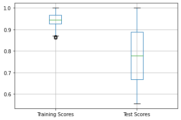

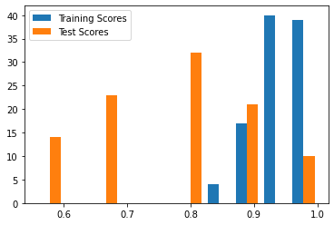

```
Confusion matrix:
[[537 142]
 [ 68 153]]
Classification report:
              precision    recall  f1-score   support

         0.0       0.89      0.79      0.84       679
         1.0       0.52      0.69      0.59       221

    accuracy                           0.77       900
   macro avg       0.70      0.74      0.71       900
weighted avg       0.80      0.77      0.78       900
```

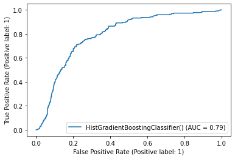

```python
training_scores_hgb_500, test_scores_hgb_500 = batch_test_classifier(features_500_days, target_500_days, 0.2, HistGradientBoostingClassifier(), '500 days survival')
```

We can see that the 500 days survival classifier performs acceptably well on test data, on average achieving about 77% prediction accuracy and with an AUC of 0.79. However, the overall accuracy rate hides an important statistic from the classification report -- very poor precision for the positive class, indicating a high number of false positives. This may be a side effect of our over-sampling strategy, where the distribution of the positive class in the training set is very different from the distribution of the test set. We also see that average training scores are much higher than test scores, which could indicate over-fitting but could also just be an artifact of our very small sample size, and our classifier not being able to learn true underlying patterns very well with such limited numbers of samples.

Next let's batch test and evaluate the performance of our 100 days survival classifier.

### 4.3 Batch testing the histogram gradient boosting 100 days survival classifier

```
Training and Test Scores Results for 100 days survival with HistGradientBoostingClassifier():
```

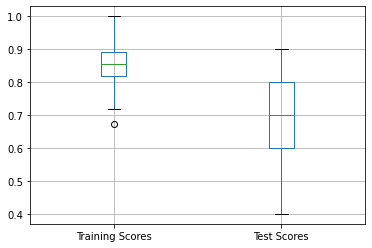

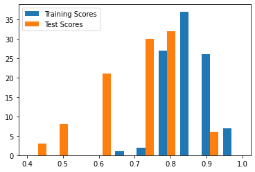

```
Confusion matrix:
[[478 178]
 [124 220]]
Classification report:
              precision    recall  f1-score   support

           0       0.79      0.73      0.76       656
           1       0.55      0.64      0.59       344

    accuracy                           0.70      1000
   macro avg       0.67      0.68      0.68      1000
weighted avg       0.71      0.70      0.70      1000
```

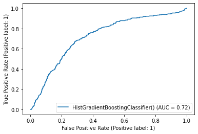

```python
training_scores_hgb_100, test_scores_hgb_100 = batch_test_classifier(features_100_days, target_100_days, 0.20, HistGradientBoostingClassifier(), '100 days survival')
```

We can see that the 100 days survival classifier has somewhat lower accuracy (on average 70% accuracy with AUC of 0.72) than the 500 days survival classifier, indicating that predicting short-term survival may be a more difficult classification task than predicting longer-term survival. Similar to the longer-term survival classifier, we see poor precision for the positive class, and much higher average training scores than test scores.

### 4.4 "Sanity test": check prediction consistency rate between the two classifiers

Another way we can evaluate the reliability of our two classifiers is to perform a simple "sanity test": how consistent are the predictions between our 100 days survival classifier and our 500 days survival classifier? That is, if the 500 days survival classifier predicts survival at 500 days, then to be logically consistent the 100 days survival classifier should also predict survival at 100 days. If the 100 days survival classifier predicts non-survival at 100 days, then for logical consistency the 500 days survival classifier should also predict non-survival at 500 days. The two classifiers were independently trained so logical consistency is not guaranteed, thus a high consistency rate between the two classifiers would be another signal that our classifiers have learned some true underlying data patterns.

We will again employ batch testing because any specific iteration may produce widely varying values depending on the specific random train-test split, due to our small sample size.

```python
def is_prediction_consistent(prediction_100_days, prediction_500_days):
    if prediction_100_days == 0 and prediction_500_days == 1:
        return False
    else :
        return True

def get_consistency_rate_for_model_predictions(y_pred_100, y_pred_500):
    total_count = y_pred_100.size
    inconsistent_prediction_count = 0
    for i in range(total_count):
        if is_prediction_consistent(y_pred_100[i], y_pred_500[i]) == False :
            inconsistent_prediction_count += 1
    return 1 - (inconsistent_prediction_count / total_count)

def test_classifier_consistency(random_state):
    model_100, _, X_test, _, _ = train_classifier(features_100_days, target_100_days, 0.2, random_state, HistGradientBoostingClassifier())
    model_500, _, _, _, _ = train_classifier(features_500_days, target_500_days, 0.2, random_state, HistGradientBoostingClassifier())
    y_pred_100 = model_100.predict(X_test)
    y_pred_500 = model_500.predict(X_test)
    return get_consistency_rate_for_model_predictions(y_pred_100, y_pred_500)
```

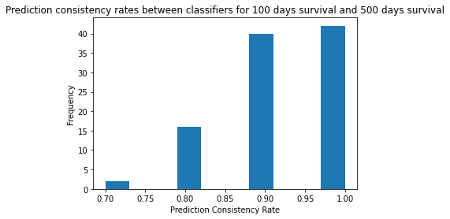

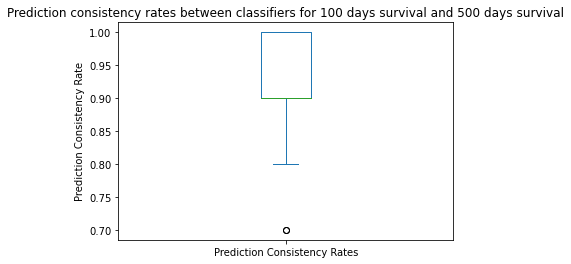

|  | Prediction Consistency Rates |
| --- | --- |
| count | 100.000000 |
| mean | 0.922000 |
| std | 0.078599 |
| min | 0.700000 |
| 25% | 0.900000 |
| 50% | 0.900000 |
| 75% | 1.000000 |
| max | 1.000000 |

```python
# test classifier consistency 100 times, and aggregate results
consistency_rates = []
for i in range(100):
    consistency_rates.append(test_classifier_consistency(i))

consistency_rates_df = pd.DataFrame(consistency_rates, columns=['Prediction Consistency Rates'])
consistency_rates_df.plot(kind='hist', legend=False)
plt.xlabel('Prediction Consistency Rate')
plt.title('Prediction consistency rates between classifiers for 100 days survival and 500 days survival')
plt.show()
consistency_rates_df.plot(kind='box')
plt.ylabel('Prediction Consistency Rate')
plt.title('Prediction consistency rates between classifiers for 100 days survival and 500 days survival')
plt.show()
consistency_rates_df.describe()
```

We achieve on average over 90% classification consistency between our two independently-trained classifiers, which is a positive signal for the reliability of our two classifiers.

## 5. Improving classification performance

In the previous section we've seen acceptable accuracy results for our 100 and 500 days survival classifiers, and high classification consistency between the two classifiers, both of which are positive signals for model reliability. In this section we'll explore ways to further improve classification performance.

### 5.1 Adding 100 days survival info to the features set for the 500 days survival classifier

One simple way we may be able to improve the accuracy of our 500 days survival classifier is to include 100 days survival data as a feature for the classifier to train on, since this extra short-term survival information should be extremely useful for predicting longer-term survival.

Let's see if adding this extra feature improves test scores:

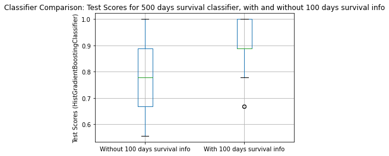

|  | Without 100 days survival info | With 100 days survival info |
| --- | --- | --- |
| count | 100.000000 | 100.000000 |
| mean | 0.766667 | 0.915556 |
| std | 0.131658 | 0.085222 |
| min | 0.555556 | 0.666667 |
| 25% | 0.666667 | 0.888889 |
| 50% | 0.777778 | 0.888889 |
| 75% | 0.888889 | 1.000000 |
| max | 1.000000 | 1.000000 |

```python
features_500_days_with_100_days_info = df_500_days_classifier.drop('Survived 500 days', axis=1) # drop only 500 days survival info but retain 100 days survival info in features set
training_scores_hgb_500_with_extra_info, test_scores_hgb_500_with_extra_info = batch_test_classifier(features_500_days_with_100_days_info, target_500_days, 0.2, HistGradientBoostingClassifier(), '500 days survival (with 100 days survival info)', False, False)
test_scores_with_extra_info_df = pd.DataFrame(np.array([test_scores_hgb_500, test_scores_hgb_500_with_extra_info]).transpose(), columns=['Without 100 days survival info', 'With 100 days survival info'])
test_scores_with_extra_info_df.boxplot()
plt.title('Classifier Comparison: Test Scores for 500 days survival classifier, with and without 100 days survival info')
plt.ylabel('Test Scores (HistGradientBoostingClassifier)')
plt.show()

test_scores_with_extra_info_df.describe()
```

Indeed, average test scores jump from 77% to 92% when we include the 100 days survival information as a feature in the 500 days survival classifier model. The drawback is that for practical purposes (in a clinical hospital environment for example), we will likely not have this extra information when we want to predict longer-term survival. To improve classifier performance without this extra information, we can explore other types of ML classifiers other than the histogram gradient boosting algorithm that we've been using.

### 5.2 Other ML classifiers: logistic regression and support vector classifier

We'll test the logistic regression and support vector classifier (SVC) and see if these algorithms outperform our previous histogram gradient boosting classifier. Logistic regression was chosen because of its ability to model non-linear variables well, and SVC was chosen because of its purported ability to perform well on small datasets.

#### 5.2.1 Data pre-processing: missing values imputation

Unlike the histogram gradient boosting classifier, the logistic regression and support vector classifiers do not accept missing values for features. So we will first need to impute any missing data. Since all the missing values in the dataset are for quantitative features, we will use the simple strategy of replacing them with the median values of those columns.

```python
def impute_values_for_features(features):
    features_with_imputed_values = features.copy()
    features_with_imputed_values['Age (years)'].fillna(df['Age (years)'].median(), inplace=True)
    features_with_imputed_values['Case Severity Score'].fillna(df['Case Severity Score'].median(), inplace=True)
    features_with_imputed_values['Creatine at 48 hours (mg/dl)'].fillna(df['Creatine at 48 hours (mg/dl)'].median(), inplace=True)
    return features_with_imputed_values

features_500_days_with_imputed_values = impute_values_for_features(features_500_days)
features_100_days_with_imputed_values = impute_values_for_features(features_100_days)
```

#### 5.2.2 Compare performance across classifiers for predicting survival at 500 days

Let's batch test and compare classification performance across the histogram gradient boosting, logistic regression, and support vector classifiers, for predicting survival at 500 days. We'll look at ROC curves, training scores, and test scores of all 3 algorithms after "batch testing" each one 100 times.

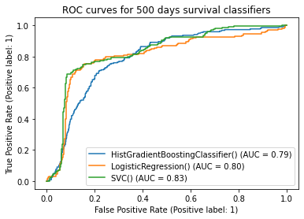

```python
from sklearn.linear_model import LogisticRegression
from sklearn.svm import SVC
fig1, ax1 = plt.subplots()
training_scores_hgb_500, test_scores_hgb_500 = batch_test_classifier(features_500_days, target_500_days, 0.2, HistGradientBoostingClassifier(), '500 days survival', False, True, ax1)
training_scores_lr_500, test_scores_lr_500 = batch_test_classifier(features_500_days_with_imputed_values, target_500_days, 0.2, LogisticRegression(), '500 days survival', False, True, ax1)
training_scores_svc_500, test_scores_svc_500 = batch_test_classifier(features_500_days_with_imputed_values, target_500_days, 0.2, SVC(), '500 days survival', False, True, ax1)
plt.title('ROC curves for 500 days survival classifiers')
plt.show()
```

The ROC curve for the support vector classifier has the highest AUC value. However, this may not necessarily translate to higher test scores. Next let's examine training and test scores for each classifier:

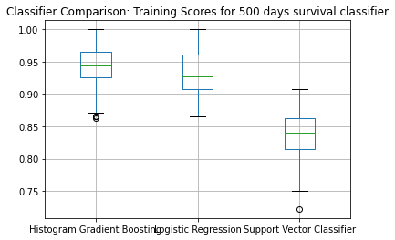

```python
training_scores_500_df = pd.DataFrame(np.array([training_scores_hgb_500, training_scores_lr_500, training_scores_svc_500]).transpose(), columns=['Histogram Gradient Boosting', 'Logistic Regression', 'Support Vector Classifier'])
training_scores_500_df.boxplot()
plt.title('Classifier Comparison: Training Scores for 500 days survival classifier')
plt.show()
```

Training scores are significantly higher for the histogram gradient boosting and logistic regression classifiers. Perhaps these algorithms are better at adapting to our data during training, or perhaps it's a sign of overfitting. Let's look at the test scores:

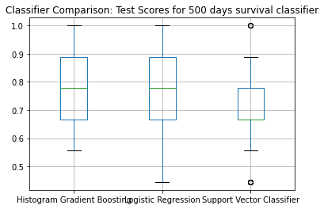

|  | Histogram Gradient Boosting | Logistic Regression | Support Vector Classifier |
| --- | --- | --- | --- |
| count | 100.000000 | 100.000000 | 100.000000 |
| mean | 0.766667 | 0.797778 | 0.718889 |
| std | 0.131658 | 0.117525 | 0.124807 |
| min | 0.555556 | 0.444444 | 0.444444 |
| 25% | 0.666667 | 0.666667 | 0.666667 |
| 50% | 0.777778 | 0.777778 | 0.666667 |
| 75% | 0.888889 | 0.888889 | 0.777778 |
| max | 1.000000 | 1.000000 | 1.000000 |

```python
test_scores_500_df = pd.DataFrame(np.array([test_scores_hgb_500, test_scores_lr_500, test_scores_svc_500]).transpose(), columns=['Histogram Gradient Boosting', 'Logistic Regression', 'Support Vector Classifier'])
test_scores_500_df.boxplot()
plt.title('Classifier Comparison: Test Scores for 500 days survival classifier')
plt.show()

test_scores_500_df.describe()
```

Test scores are also higher on average for the histogram gradient boosting and logistic regression classifiers, even though the support vector classifier had a higher AUC value than either of them. This shows that higher AUC value does not necessarily translate to better classification performance.

The logistic regression classifier seems to have the best mean classification accuracy, though median accuracy is identical to the histogram gradient boosting classifier. However, despite having higher mean classification accuracy, the logistic regression classifier also has a lower minimum than the histogram gradient boosting classifier. I'm not sure how to explain this; perhaps the logistic regression algorithm is more vulnerable to particularly "unlucky" train-test splits due to an artifact of our small dataset size.

Next we'll compare classification performance for predicting survival at 100 days rather than 500 days.

#### 5.2.3 Compare performance across classifiers for predicting survival at 100 days

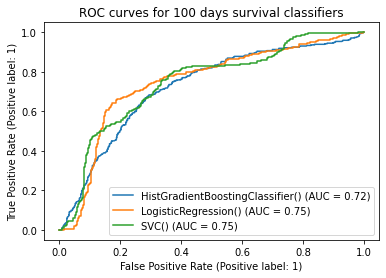

```python
fig2, ax2 = plt.subplots()
training_scores_hgb_100, test_scores_hgb_100 = batch_test_classifier(features_100_days, target_100_days, 0.20, HistGradientBoostingClassifier(), '100 days survival', False, True, ax2)
training_scores_lr_100, test_scores_lr_100 = batch_test_classifier(features_100_days_with_imputed_values, target_100_days, 0.2, LogisticRegression(), '100 days survival', False, True, ax2)
training_scores_svc_100, test_scores_svc_100 = batch_test_classifier(features_100_days_with_imputed_values, target_100_days, 0.2, SVC(), '100 days survival', False, True, ax2)
plt.title('ROC curves for 100 days survival classifiers')
plt.show()
```

Both the logistic regression and support vector classifiers have higher AUC values under their ROC curves than the histogram gradient boosting classifier. But as we saw previously with predicting survival at 500 days, this does not necessarily translate to higher classification accuracy during testing. Let's look at the training and test scores:

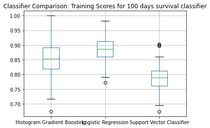

```python
training_scores_100_df = pd.DataFrame(np.array([training_scores_hgb_100, training_scores_lr_100, training_scores_svc_100]).transpose(), columns=['Histogram Gradient Boosting', 'Logistic Regression', 'Support Vector Classifier'])
training_scores_100_df.boxplot()
plt.title('Classifier Comparison: Training Scores for 100 days survival classifier')
plt.show()
```

Training scores are highest for the logistic regression classifier. Let's see if that's also true for test scores:

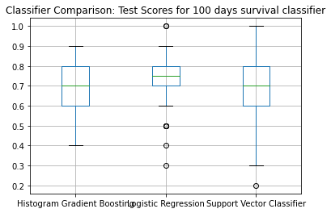

|  | Histogram Gradient Boosting | Logistic Regression | Support Vector Classifier |
| --- | --- | --- | --- |
| count | 100.000000 | 100.000000 | 100.000000 |
| mean | 0.698000 | 0.740000 | 0.693000 |
| std | 0.117189 | 0.126331 | 0.135031 |
| min | 0.400000 | 0.300000 | 0.200000 |
| 25% | 0.600000 | 0.700000 | 0.600000 |
| 50% | 0.700000 | 0.750000 | 0.700000 |
| 75% | 0.800000 | 0.800000 | 0.800000 |
| max | 0.900000 | 1.000000 | 1.000000 |

```python
test_scores_100_df = pd.DataFrame(np.array([test_scores_hgb_100, test_scores_lr_100, test_scores_svc_100]).transpose(), columns=['Histogram Gradient Boosting', 'Logistic Regression', 'Support Vector Classifier'])
test_scores_100_df.boxplot()
plt.title('Classifier Comparison: Test Scores for 100 days survival classifier')
plt.show()

test_scores_100_df.describe()
```

Average (mean and median) test scores are higher for the logistic regression classifier than for either of the other two algorithms. We also note that test scores for predicting survival at 100 days are lower for all classifiers than for predicting survival at 500 days. Predicting short-term survival seems to be a harder classification task than predicting longer-term survival for all classifiers.

We've now seen that the logistic regression classifier seems to on average outperform the other algorithms for predicting survival at both 500 days and 100 days. Next we'll get the full set of batch test statistics for this classifier.